# Racial Inequality in the United States

Mykyta Lepikash

2022-11-20

## Abstract

From education, health, and poverty to culture, environmental harm, the economy, and beyond, all aspects of American society are shaped in some way by racial inequity. I am concerned about this topic because it is an important problem that impacts everybody, no matter their skin colour.

## Introduction

Racial inequality among black people has long been a blatant circumstance of the American experience. These circumstances range from the horrible realities of African enslavement in the 1700s to the restrictions on human rights and unfair practices such as literacy tests before being permitted housing and voting in the 1950s. Racial inequality in America has been manifested in various forms for centuries. For example, the American criminal legal system was set up to enforce slavery and has been used ever since to over-police and over-arrest people of color, especially Black people. In the modern day, there is a considerable gap between races regarding employment, wealth, being convicted, and even the chances of getting a high score on standardized tests. Reflecting centuries of white privilege has made it difficult for people of color to achieve equal rights and economic security, which impacts and dictates their daily lives. This is a complicated and essential problem affecting society in countless ways, such as crime and employment rates, economic growth, education, healthcare, etc. This report will try to expose the patterns of inequality across the U.S. by using imprisonment jail data

## Data Summary

In 1985 the total amount of black inmates was 86947, nowadays the number has changed to the 247546, and in 35 years, the total number has increased by 160599.This data shows that the problem only worsens over time. Currently, the state with the highest number of black inmates is Georgia. Even though the state is 8th by the population in the U.S., it has the biggest number of total black inmates, which raises the question of why it happens there and why black people are sentenced and charged there more than anywhere else.

## Growth of the U.S. Prison Population

[figure not shown]

## Growth of Prison Population by States

[figure not shown]

## Patterns Of Inequality by race in jail

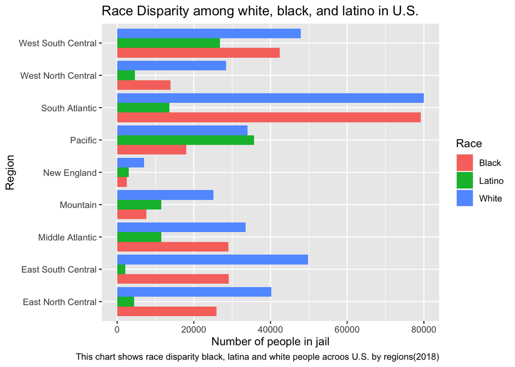

This chart answers how different races spread in jail by region. For each region, it provides a comparison between 3 races. For example, out of all regions, only in the Pacific, there are more Latina people than black and white, indicating racial inequality and asking us why it mainly happens there.

## Patterns of Inequality Among Black People By States

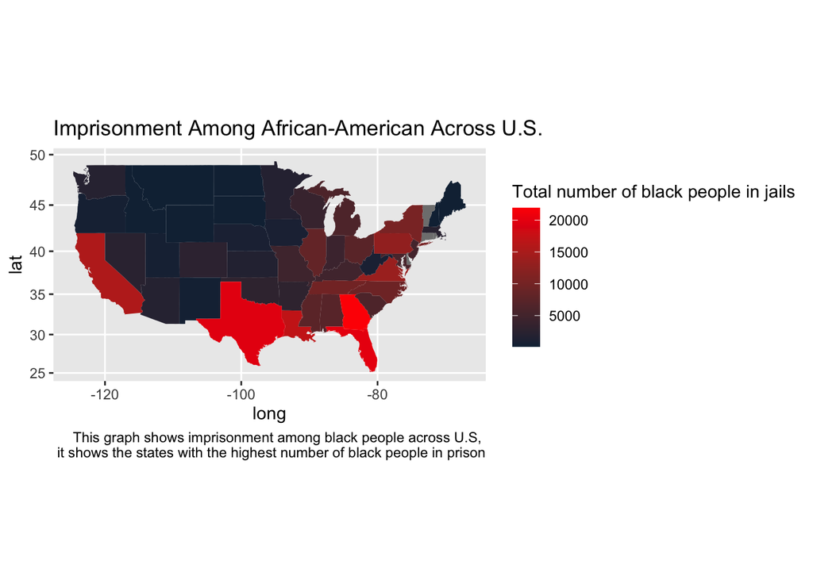